# meth05_regional_analysis.R

r2026295

2023-05-08

```r
.libPaths( c('.Rpackages',.libPaths() ) )
```

# Regional DNA methylation analysis using DMRcate

Using data preprocessed in our script:  
meth01_process_data.R

```r
options(warn=-1)
suppressMessages(library(data.table))
suppressMessages(library(stringi))
suppressMessages(library(limma))
suppressMessages(library(minfi))
suppressMessages(library(missMethyl))
suppressMessages(library(ChAMP))
options(warn=0)
```

load the data

```r
load("data/processed.rda")

betas.clean <- beta[manifest[manifest$probe_type=="cg" & !chr %in% c("X","Y")]$index,]
```

# Introduction to differential variability analysis

see [Phipson and Oshlack. Genome Biol 2014](https://pubmed.ncbi.nlm.nih.gov/25245051/). Impute missing Beta-values (varFit will produce an error with missingness)

```r
sum(is.na(betas.clean))
```

```
## [1] 30426
```

```r
# the champ.impute function prints a lot of information when running, so we'll use this function to supress the progress messages
hush=function(code){
  sink("NUL") # use /dev/null in UNIX
  tmp = code
  sink()
  return(tmp)
}
betas.impute <- hush(champ.impute(beta=betas.clean, pd=pheno, k=5, ProbeCutoff=0.2, SampleCutoff=0.1))
```

```
## [===========================]
```

```
## [<<< ChAMP.IMPUTE START >>>>]
```

```
## <method>:Combine. (Suitable for Large Data Set)
```

```
## (1): 0 Samples contain 0.1 or above NA will be removed.
```

```
## (2): 1173 Probes contain 0.2 or above NA will be removed.
```

```
## (3): The rest NA are imputed by KNN method which parameter k as 5.
```

```
## [<<<<< ChAMP.IMPUTE END >>>>]
```

```
## [===========================]
```

```r
betas.impute <- betas.impute$beta
```

coef parameter in varFit states which columns of design matrix correspond to the intercept and variable of interest If Beta-values are used, a lofit transformation is performed within the varFit function

```r
model <- model.matrix( ~smoker+sex+CD4+CD8+NK+B+MO+GR,data=pheno)
head(model)
```

```
##   (Intercept) smokersmoker sexm        CD4        CD8           NK          B         MO        GR
## 1           1            1    1 0.04082631 0.05057384 0.0007356247 0.03217004 0.05927233 0.8165537
## 2           1            1    1 0.09065380 0.05035808 0.0380600531 0.01869650 0.07275495 0.7427139
## 3           1            1    1 0.05119496 0.03016833 0.0516722297 0.02494734 0.05162970 0.7961799
## 4           1            1    1 0.08636995 0.03420980 0.0388351910 0.02278589 0.08911712 0.7437603
## 5           1            1    0 0.12041583 0.02867331 0.0280640200 0.03466659 0.08156461 0.7230753
## 6           1            1    1 0.10917956 0.04243298 0.0361986341 0.03315951 0.05717037 0.7230716
```

```r
EWAS.diffVar <- varFit(betas.impute, design=model, coef=c(1,2))
Top.diffVar <- topVar(EWAS.diffVar, coef=2, number=10, sort =TRUE)
Top.diffVar
```

[output not shown]

Bind results with annotation

```r
Annot <- as.data.frame(getAnnotation(IlluminaHumanMethylation450kanno.ilmn12.hg19))
Annot.Top.diffVar <- Annot[match(rownames(Top.diffVar),Annot$Name),]
Annot.Top.diffVar <- Annot.Top.diffVar[,c("UCSC_RefGene_Name","UCSC_RefGene_Group","Relation_to_Island","chr","pos")]
Top.diffVar <- cbind(Top.diffVar, Annot.Top.diffVar)
```

Order by chr and chromosomal position

```r
Top.diffVar$chr <- as.numeric(gsub("chr", "", Top.diffVar$chr))
Top.diffVar[,c(2,6)] <- round(Top.diffVar[,c(2,6)],2)
Top.diffVar[order(Top.diffVar$chr, Top.diffVar$pos),c(2,5,6,7,10,11)]
```

```
##            LogVarRatio      P.Value Adj.P.Value UCSC_RefGene_Name chr       pos
## cg03206401        4.62 3.896491e-06        0.53            TUBA3E   2 130956119
## cg01397495       -4.34 2.145091e-07        0.10                     2 136496804
## cg22140756        3.89 1.318328e-05        0.73                     2 177895827
## cg03269667       -3.96 8.586027e-06        0.58             CPNE9   3   9744891
## cg01347786        4.15 1.563711e-05        0.73 RBMS3;RBMS3;RBMS3   3  29517179
## cg03955698       -3.32 1.390282e-05        0.73           MRPS18B   6  30587655
## cg21173402        4.17 8.663885e-06        0.58                     8    610095
## cg03704393       -4.20 6.795222e-07        0.16            ZNF169   9  97042001
## cg19754622       -1.75 7.157382e-06        0.58            STK32C  10 134045578
## cg19599395       -3.70 4.518111e-06        0.53              ZFR2  19   3837031
```

Although no CpGs meet FDR significance, we can see differences in variability among the top sites

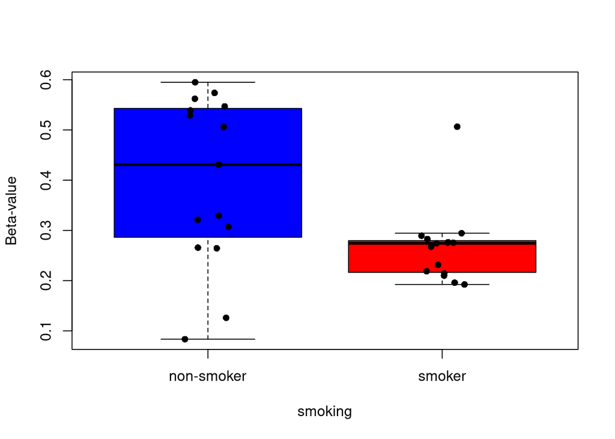

```r
cpg1 <- data.frame(id = colnames(betas.impute), beta = betas.impute[rownames(betas.impute) == 'cg19754622',])
cpg1 <- merge(cpg1, pheno[,c('gsm', 'smoker')], by.x = 'id', by.y = 'gsm')
cpg1$smoker <- as.numeric(factor(cpg1$smoker))

cpg2 <- data.frame(id = colnames(betas.impute), beta = betas.impute[rownames(betas.impute) == 'cg21173402',])
cpg2 <- merge(cpg2, pheno[,c('gsm', 'smoker')], by.x = 'id', by.y = 'gsm')
cpg2$smoker <- as.numeric(factor(cpg2$smoker))

boxplot(cpg1$beta ~ cpg1$smoker, col = c("blue", "red"), outline = F, xlab = 'smoking', ylab = 'Beta-value', names = c("non-smoker", "smoker"));points(jitter(cpg1$smoker, amount = 0.1), cpg1$beta, pch = 16)
```

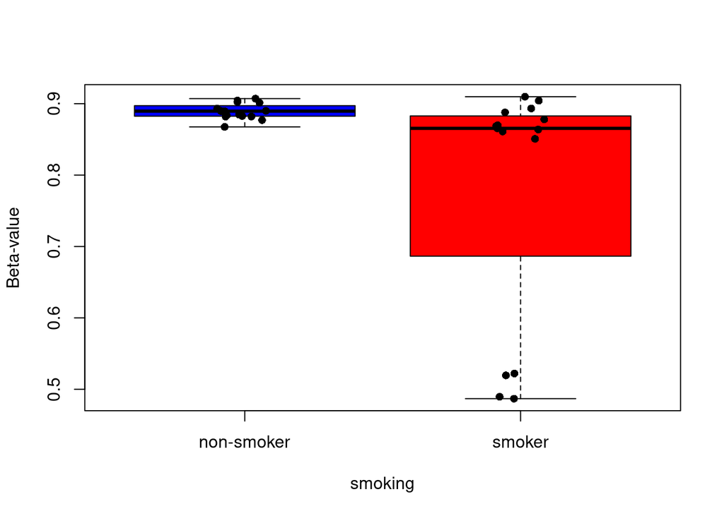

```r
boxplot(cpg2$beta ~ cpg2$smoker, col = c("blue", "red"), outline = F, xlab = 'smoking', ylab = 'Beta-value', names = c("non-smoker", "smoker"));points(jitter(cpg1$smoker, amount = 0.1), cpg2$beta, pch = 16)
```

Note that diffVar results may be influenced by outliers, and therefore it is helpful to visually inspect results.

```r
rm(Annot.Top.diffVar,Top.diffVar,EWAS.diffVar,betas.impute,cpg1,cpg2);gc()
```

```
##             used   (Mb) gc trigger   (Mb)  max used   (Mb)
## Ncells  23869829 1274.8   45660741 2438.6  45660741 2438.6
## Vcells 285385911 2177.4  597839786 4561.2 597839786 4561.2
```

# Introduction to regional analyses with DMRcate

```r
suppressMessages(library(DMRcate)) # Popular package for regional DNA methylation analysis
```

Regions are now agglomerated from groups of significant probes Let’s run the regional analysis using the Beta-values from our preprocessed data

```r
myannotation <- cpg.annotate("array", na.omit(betas.clean), analysis.type="differential",arraytype="450K",
                             what="Beta",design=model, coef=2)
```

```
## Your contrast returned 16 individually significant probes; a small but real effect. Consider manually setting the value of pcutoff to return more DMRs, but be warned that doing this increases the risk of Type I errors.
```

```r
# set analysis.type = "diffVar" to return differentially variable methylated regions
```

Regions are now agglomerated from groups of significant probes where the distance to the next consecutive probe is less than lambda nucleotides away

```r
dmrcoutput.smoking <- dmrcate(myannotation, lambda=1000, C=2)
```

[output not shown]

[output not shown]

[output not shown]

[output not shown]

[output not shown]

[output not shown]

[output not shown]

[output not shown]

[output not shown]

[output not shown]

[output not shown]

[output not shown]

[output not shown]

[output not shown]

[output not shown]

[output not shown]

[output not shown]

[output not shown]

[output not shown]

[output not shown]

[output not shown]

[output not shown]

```
## Demarcating regions...
```

```
## Done!
```

Let’s look at the results

```r
results.ranges <- extractRanges(dmrcoutput.smoking, genome = "hg19")
```

```
## snapshotDate(): 2023-04-24
```

```
## see ?DMRcatedata and browseVignettes('DMRcatedata') for documentation
```

```
## loading from cache
```

```r
results.ranges
```

```
## GRanges object with 3 ranges and 8 metadata columns:
##       seqnames              ranges strand |   no.cpgs min_smoothed_fdr    Stouffer       HMFDR      Fisher
##          <Rle>           <IRanges>  <Rle> | <integer>        <numeric>   <numeric>   <numeric>   <numeric>
##   [1]     chr2 233284112-233285289      * |         5      3.85029e-53 1.56085e-06 0.004432650 6.81792e-06
##   [2]     chr5       373299-373378      * |         2      5.35817e-30 2.86779e-04 0.000257445 1.75338e-04
##   [3]     chr6   29599160-29599390      * |         9      5.97539e-29 1.04598e-03 0.140779463 1.16986e-02
##          maxdiff   meandiff overlapping.genes
##        <numeric>  <numeric>       <character>
##   [1] -0.2367534 -0.1309786        AC068134.5
##   [2] -0.2855068 -0.2483577              AHRR
##   [3] -0.0938554 -0.0687247            GABBR1
##   -------
##   seqinfo: 3 sequences from an unspecified genome; no seqlengths
```

Plot the DMR using the Gviz if you are interested in plotting genomic data the Gviz is extremely useful Let’s look at the second region

```r
results.ranges[2]
```

```
## GRanges object with 1 range and 8 metadata columns:
##       seqnames        ranges strand |   no.cpgs min_smoothed_fdr    Stouffer       HMFDR      Fisher   maxdiff
##          <Rle>     <IRanges>  <Rle> | <integer>        <numeric>   <numeric>   <numeric>   <numeric> <numeric>
##   [1]     chr5 373299-373378      * |         2      5.35817e-30 0.000286779 0.000257445 0.000175338 -0.285507
##        meandiff overlapping.genes
##       <numeric>       <character>
##   [1] -0.248358              AHRR
##   -------
##   seqinfo: 3 sequences from an unspecified genome; no seqlengths
```

```r
# set up the grouping variables and colours
pheno$smoker<-as.factor(pheno$smoker)
cols = c("magenta","red")[pheno$smoker]
names(cols) = levels(pheno$smoker)[pheno$smoker]
```

Draw the plot a DMR

```
## snapshotDate(): 2023-04-24
```

```
## see ?DMRcatedata and browseVignettes('DMRcatedata') for documentation
```

```
## loading from cache
```

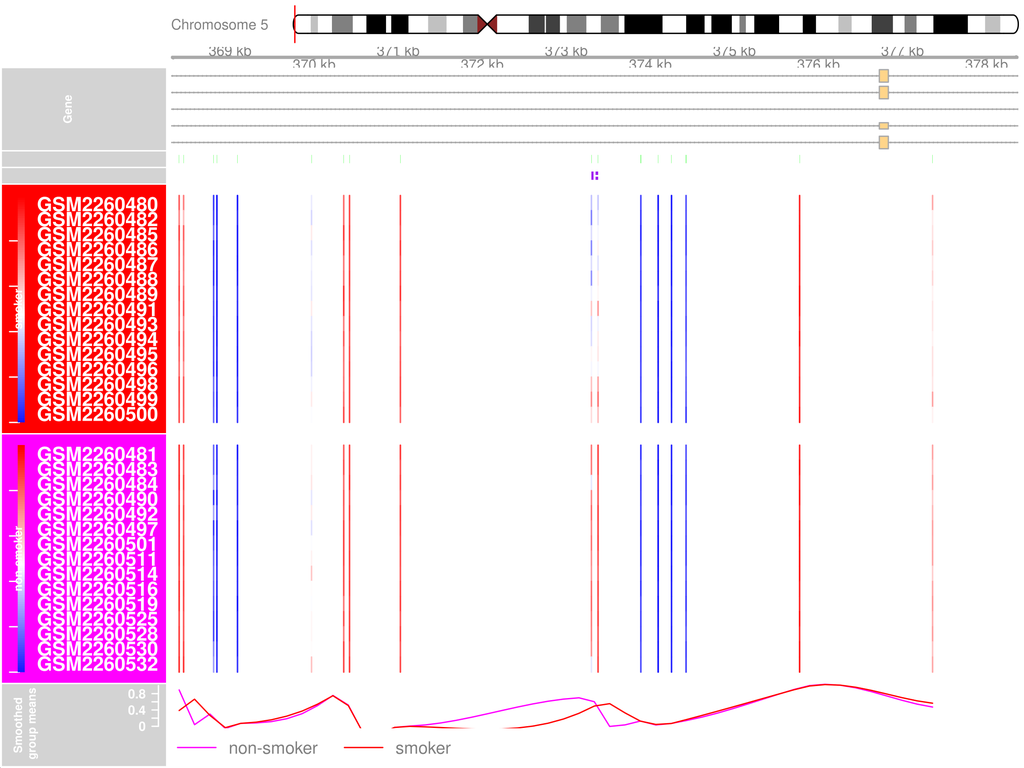

```r
DMR.plot(ranges=results.ranges, dmr=2, CpGs=betas.clean, phen.col=cols, what = "Beta",
         arraytype = "450K", pch=16, toscale=TRUE, plotmedians=TRUE,
         genome="hg19", samps=1:nrow(pheno))
```

Clean data

```r
rm(dmrcoutput.smoking,myannotation);gc()
```

```
##             used   (Mb) gc trigger   (Mb)  max used   (Mb)
## Ncells  23927129 1277.9   45660741 2438.6  45660741 2438.6
## Vcells 285441979 2177.8  597839786 4561.2 597839786 4561.2
```

# Introduction to regional analyses with comb-p

see [Pedersen et al. Bioinformatics 2012](https://academic.oup.com/bioinformatics/article/28/22/2986/240603).

```r
suppressMessages(library(ENmix))
```

Input is a data frame with colnames “chr”, “start”, “end”, “p” and “probe”

```r
# Using p-values from limma
EWAS.limma <- eBayes(lmFit(betas.clean, design=model))
```

```r
EWAS.limma <- topTable(EWAS.limma, coef=2, number=Inf, sort.by="p")
EWAS.limma <- EWAS.limma[!is.na(EWAS.limma$logFC),]
# Add chr and pos
EWAS.limma <- cbind(EWAS.limma, chr = Annot[,"chr"][match(rownames(EWAS.limma), rownames(Annot))])
EWAS.limma <- cbind(EWAS.limma, pos = Annot[,"pos"][match(rownames(EWAS.limma), rownames(Annot))])
EWAS.limma$end <- EWAS.limma$pos
# keep only needed columns
EWAS.combp <- EWAS.limma[,c("chr", "pos", "end", "P.Value")]
colnames(EWAS.combp) <- c("chr", "start", "end", "p")
EWAS.combp$probe = rownames(EWAS.combp)
EWAS.limma$chr <- as.numeric(gsub("chr", "", EWAS.limma$chr)) # chr as numeric
# Run combp. Results saved in working directory. For efficiency, we'll use output already generated.
# combp(EWAS.combp, region_plot = F, mht_plot = F, dist.cutoff=1000, seed=0.001, verbose = T) # dist.cutoff = maximum distrance between basepairs to combine adjacent DMRs; seed = FDR significance threshold for initial selection of DMRs
# read output
combp.result = read.csv('combp/resu_combp.csv')
combp.result
```

```
##      chr     start       end            p          fdr        sidak nprobe
## 1   chr2 233284401 233284934 1.038837e-19 2.597091e-18 0.000000e+00      3
## 2   chr6  29599011  29599390 4.106060e-16 5.132576e-15 5.517808e-13     10
## 3   chr6  43214395  43214590 1.085532e-10 7.551424e-10 2.621208e-07      3
## 4   chr5    373298    373378 1.208228e-10 7.551424e-10 7.111355e-07      2
## 5  chr10 134043617 134043897 7.326113e-10 3.663057e-09 1.231995e-06      5
## 6  chr17  46641707  46642104 1.499681e-09 6.248671e-09 1.778696e-06      4
## 7  chr16  85518791  85519061 3.048030e-09 1.088582e-08 5.315546e-06      4
## 8  chr15  74218696  74218921 7.865231e-09 2.457885e-08 1.645959e-05      8
## 9  chr17   4835340   4835627 9.322931e-09 2.589703e-08 1.529540e-05      4
## 10 chr17  17603530  17603837 2.026510e-08 4.844530e-08 3.108117e-05      4
## 11  chr5    399359    399360 2.131593e-08 4.844530e-08 9.986662e-03      1
## 12  chr4 188916580 188916943 5.049913e-08 1.052065e-07 6.550232e-05     10
## 13 chr19  17000584  17000585 1.482692e-07 2.692286e-07 6.743304e-02      1
## 14  chr1 151509722 151509825 1.510555e-07 2.692286e-07 6.903083e-04      2
## 15 chr14  81425911  81426015 1.615371e-07 2.692286e-07 7.310952e-04      3
## 16  chr6  30720079  30720108 2.286381e-07 3.572471e-07 3.705429e-03      2
## 17 chr14 103593502 103593520 3.281402e-06 4.825591e-06 8.225740e-02      3
## 18  chr2 145278563 145278564 4.215720e-05 5.855166e-05 1.000000e+00      1
## 19 chr16  47048003  47048107 7.450882e-05 9.803792e-05 2.863429e-01      3
## 20  chr1  76262593  76262648 3.002875e-04 3.753593e-04 9.235551e-01      2
## 21  chr1   2058416   2058417 8.740644e-04 1.040553e-03 1.000000e+00      1
## 22  chr5 143191770 143191771 1.597709e-02 1.815579e-02 1.000000e+00      1
## 23  chr5 178986619 178986620 2.252553e-02 2.448427e-02 1.000000e+00      1
## 24  chr6  31696422  31696462 5.761690e-02 6.001761e-02 1.000000e+00      2
## 25  chr6  30038719  30038791 6.916129e-01 6.916129e-01 1.000000e+00      3
```

```r
# regions chr2:233284401-233284934, chr6:29599011-29599390, and chr5:373298-373378 overlap with DMRcate results
# comb-p has higher power to detect small effect sizes, but increased Type I error; see [Malid et al. Briefings in Bioinformatics 2019](https://academic.oup.com/bib/article/20/6/2224/5096828)
```

Other popular options for conducting Regional DNA methylation analysis in R are Aclust and bumphunter Visualizing DMPs and DMRs using EWASplot

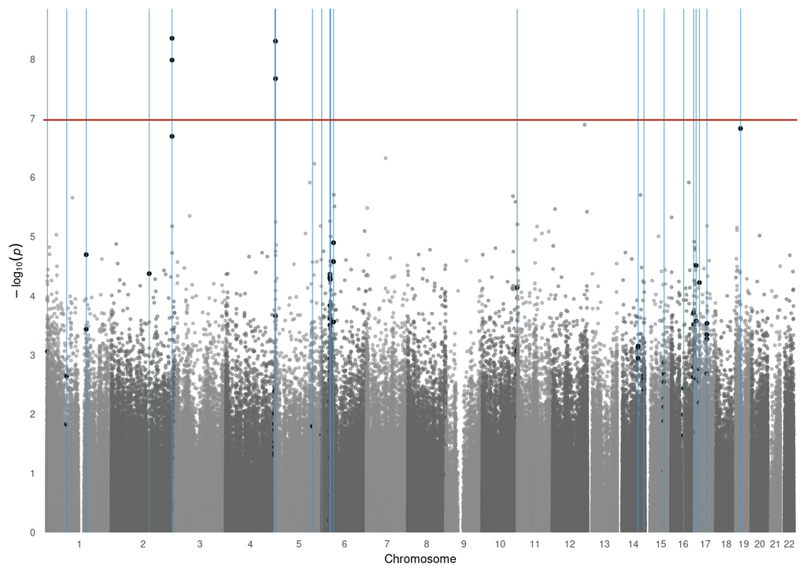

```r
suppressMessages(library(ggplot2))
suppressMessages(library(EWASplot))
manhattan_plot(probe = EWAS.limma, region = combp.result)
```

# Introduction to pathway analysis with gometh

see [Geeleher et al. Bioinformatics 2013](https://academic.oup.com/bioinformatics/article/29/15/1851/265573?login=false).

```r
keggResult = gometh(sig.cpg = rownames(EWAS.limma)[EWAS.limma$adj.P.Val < 0.05], all.cpg = rownames(EWAS.limma), collection = 'KEGG')
```

```
## All input CpGs are used for testing.
```

```r
keggResult = keggResult[order(keggResult$P.DE),]
head(keggResult)
```

```
##                                      Description   N DE       P.DE FDR
## hsa04610     Complement and coagulation cascades  83  1 0.01741421   1
## hsa00310                      Lysine degradation  60  1 0.01837279   1
## hsa04611                     Platelet activation 123  1 0.03511888   1
## hsa04015                  Rap1 signaling pathway 207  1 0.06317008   1
## hsa04080 Neuroactive ligand-receptor interaction 344  1 0.08515715   1
## hsa05200                      Pathways in cancer 508  1 0.14357727   1
```

Clean data

```r
rm(combp.result, EWAS.limma, EWAS.combp);gc()
```

```
##             used   (Mb) gc trigger   (Mb)  max used   (Mb)
## Ncells  23891751 1276.0   45660742 2438.6  45660742 2438.6
## Vcells 285429092 2177.7  597839786 4561.2 597839786 4561.2
```

# Predicting smoking with EpiSmokEr

see [Bollepalli, Sailalitha, et al. Epigenomics 2019](https://pubmed.ncbi.nlm.nih.gov/31466478/).

```r
suppressMessages(require(EpiSmokEr))
# Make sure rows of pheno match betas column names
rownames(pheno)<-pheno$gsm
identical(colnames(betas.clean),rownames(pheno))
```

```
## [1] TRUE
```

```r
# pheno needs a column for sex,in the format of 1 and 2 representing men and women respectively
pheno$sex<-ifelse(pheno$sex=="m",1,2)
# 121 CpGs are used selected by LASSO along with Sex to get 3 categories (current, former and never smokers)
result <- epismoker(dataset=betas.clean, samplesheet = pheno, method = "SSt")
```

```
## <<<<< Predicting Smoking Statuses >>>>>
```

```
## Replacing samples with NAs in methylation data with 0.5.
```

```
## Dataset has 121 of 121 CpGs required for smoking status estimation.
```

```
## Replacing samples with NAs in methylation data with 0.5.
```

```
## Dataset has 121 of 121 CpGs required for smoking status estimation.
```

```
## Replacing samples with NAs in methylation data with 0.5.
```

```
## Dataset has 121 of 121 CpGs required for smoking status estimation.
```

```
## <<<<< Prediction of Smoking Statuses Completed >>>>>
```

```r
# Let's look how well the prediction performed
table(pheno$smoker,result$PredictedSmokingStatus)
```

```
##
##              Current Smoker Never Smoker
##   non-smoker              0           15
##   smoker                 14            1
```

```r
rm(list = ls());gc()
```

```
##             used   (Mb) gc trigger   (Mb)  max used   (Mb)
## Ncells  23890832 1276.0   45660742 2438.6  45660742 2438.6
## Vcells 250191800 1908.9  597839786 4561.2 597839786 4561.2
```

End of script 05